# RAND Algorithmic Equity Tool: Tutorial

Inez Khan, Irineo Cabreros, and Joshua Snoke

# 1 Introduction

In recent years, there has been a growing awareness that Machine Learning (ML) algorithms can reinforce or exacerbate human biases. The RAND Algorithmic Equity Tool was developed to help identify and mitigate biases in algorithms that assist in decision-making processes. In particular, the tool helps users visualize tradeoffs, such as diminished predictive accuracy, that are inherent to enforcing equity. This tool was produced as part of a research effort for RAND, with the goal of assisting the Department of Defense (DoD) as they invest in the development of ML algorithms for a growing number applications. The companion report that further discusses this tool and a framework for reducing inequities are in Cabreros et al. (2023).

While ML algorithms are deployed in a wide variety of applications, this tool is specifically designed for a algorithms that assist in decision-making processes. In particular, this tool is useful when algorithmic output is used to influence binary decisions about individuals. A hypothetical example within this framework is an algorithm that produces individual-level employee performance scores, which are subsequently considered in promotional decisions.

## 1.1 Binary Classification Setup

Because this tool is currently designed for binary decision processes only, we briefly describe the binary classification setup in this section. Binary classification algorithms may be used to influence binary decisions, such as the decision to promote or not promote an individual. We refer to binary predictions as positive or negative, with positive corresponding to the assumed beneficial outcome, such as promotion. Often algorithmic output takes the form of predicted probabilities, which are then transformed to binary values based on a cutoff threshold. For example, a binary classification algorithm may predict promotion for a particular individual if the predicted probability of promotion is greater than 0.5 (or some other cutoff value).

Classification algorithms are trained on historical data for which the true outcome is observed. Performance properties of an algorithm are derived by comparing algorithm predictions for historical data to historical outcomes. In the case of binary classification, there are four possible outcomes for each prediction: *true positive*, *false positive*, *true negative*, and *false negative*. These possibilities are summarized in Figure 1, which is commonly referred to as the *confusion matrix*. *False positives* and *false negatives* correspond to prediction errors: the algorithmic prediction and true outcome are not the same. For instance, an individual who was in fact promoted but was not predicted to be promoted is a *false negative*. Conversely, an individual who was in fact not promoted but was predicted to be promoted is a *false positive*.

Algorithmic performance can be described by various different error rates. For instance, the *false positive rate* refers to the proportion of incorrect predictions made within the population of truly negative individuals. Likewise, the *false negative rate* refers to the proportion of incorrect predictions made within the population of truly positive individuals. The *overall error rate* of an algorithm refers to the proportion incorrect predictions made in the entire population.

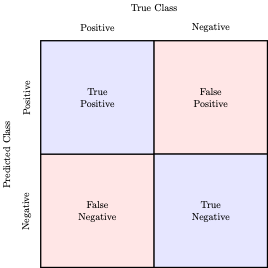

Figure 1: Confusion matrix for the binary classification problem. Red cells indicate incorrect predictions, while blue cells indicate correct predictions

## 1.2 Equity Definitions

Equity definitions concern properties of algorithmic predictions with respect to a *protected characteristic* (e.g., race) which has several *levels* (e.g., Black, white, and Hispanic). There are many different ways to define equity, and we will provide a very brief overview of several of the most important ones in this subsection.

A simple equity definition is that of *statistical parity*. This definition requires that positive predictions occur at equal rates for each level of the protected class. When statistical parity holds, the demographics of the population predicted to belong to the positive class match the demographics of the entire population. A variant on statistical parity is *conditional statistical parity*, in which statistical parity holds conditional on a subset of important covariates X. Many additional equity concepts are constructed by comparing different error rates across levels of a protected characteristic. For example, an important equity definition is that of *false negative rate balance* (false negative rate balance is equivalent to *true positive rate balance*) For the case of promotions, false negative rate balance may require that the algorithm does not. erroneously predict non-promotion for one race at a higher rate than another. *False positive rate balance* is defined analogously (false positive rate balance is equivalent to *true negative rate balance*). *Equalized odds* is attained when both false positive rate and false negative rate balance is attained by an algorithm. The table below provides mathematical definitions many of the common equity concepts. In this table, Y is the binary outcome, Yˆ is the algorithmic prediction, G is a protected characteristic, and X are additional covariates.

| Row names | Values |
| --- | --- |
| Statistical parity | $P(\hat Y = 1\|G = g) = P(\hat Y = 1)$ |
| Conditional statistical parity | $P(\hat Y = 1\|G = g, X = x) = P(\hat Y = 1\| X = x)$ |
| False positive rate balance | $P(\hat Y = 1\|Y = 0, G = g) = P(\hat Y = 1\| Y = 0)$ |
| False negative rate balance (Equal opportunity) | $P(\hat Y = 0\|Y = 1, G = g) = P(\hat Y = 0\| Y = 1)$ |
| Positive predictive value balance | $P(Y = 1\|\hat Y = 1, G = g) = P(Y = 1\| \hat Y = 1)$ |
| Negative predictive value balance | $P(Y = 0\|\hat Y = 0, G = g) = P(Y = 0\| \hat Y = 0)$ |
| Equalized odds | False positive rate balance & False negative rate balance |
| Conditional use accuracy equality | Positive predictive value balance & Negative predictive value balance |
| Overall accuracy equality | $P(\hat Y = Y\|G = g) = P(\hat Y = Y)$ |

Another common equity definition is *fairness through unawareness*. This definition simply requires that protected characteristics are removed from any input data upstream of algorithmic training. With respect to race, fairness through unawareness intuitively captures the notion of a “race-blind” decision. Despite its simplicity, many have noted that fairness through unawareness is a problematic notion within the ML framework. This is because simply removing protected characteristics may not actually remove their influence from predictions. For example, even if race is removed from the input data, an individual’s race may be predicted with high confidence from other variables that remain in the data, such as geography.

## 1.3 Approaches to Enforcing Equity

The fairness literature has developed many methods to enforce fairness. These methods differ both in the fairness criteria they enforce as well as the stage in the algorithm at which the method intervenes. Methodologies are typically categorized into three classes: pre-processing, in-processing, and post-processing (Berk et al., 2018). Pre-processing refers to any method that alters the input data before it is used by the algorithm to produce predictions. In-processing refers to any corrective measure that intervenes during the ML training process. Finally, post-processing methods are applied entirely downstream of training the ML algorithm, directly adjusting the algorithmic predictions themselves.

Figure 2 summarizes the distinction between these methods. The RAND Algorithmic Equity Tool implements both pre-processing and post-processing methods, but not in-processing methods. This is because pre-processing and post-processing methods are implemented independently from the development of the predictive ML algorithm and are therefore easier to apply in practice. By contrast, in-processing methods require more customized implementation. We provide further details of the pre- and post-processing methods implemented in the RAND Algorithmic Equity Tool below.

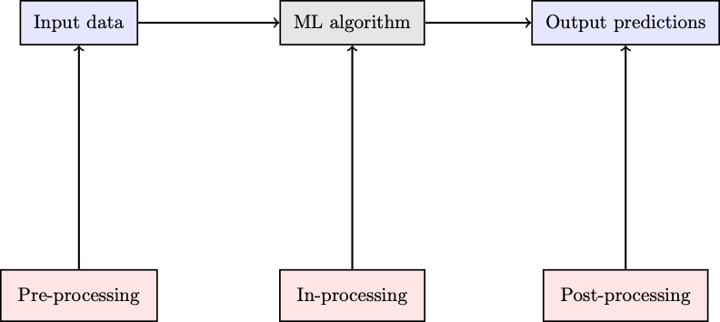

Figure 2: Methods for enforcing equity constraints

# 2 Tool Overview

The RAND ML Equity tool contains five tabs with features that assess the equity properties of a model and adjust model input/output to meet equity goals. The subsections below provide details for each of these tabs.

The tool works in common browsers such as Google Chrome, Firefox, Microsoft Edge, and Safari, but there may be minor differences in user layout depending on the browser. All data must be input as a .csv file and include a categorical variable named ‘G’; this is the protected characteristic (e.g., gender or race) with respect to which equity is being assessed. Different tabs have different additional data requirements.

We note that in any real-world application of our tool, legal considerations and institutional policies may constrain the types of interventions possible when enforcing equity criteria as demonstrated in this tutorial. See Cabreros et al. (2023) for a more detailed discussion of this point.

## 2.1 Comparing Models

The ‘Comparing Models’ tab allows you to compare equity performance across different models. One can use this tab to assess the tradeoffs across different candidate models or the same model with different pre-processing methods applied to the data (described below). This tab allows for the comparison of 2-5 models. A dataset for each model must be uploaded and contain the following three variables, named as follows:

1. **Y**: The ground truth of the observation. It must be a binary indicator. The tool currently does not allow continuous or categorical outcomes for this tab.
2. **G**: A categorical variable the identifies the protected characteristic of the observation and the variable you would want to increase equity over.
3. **Yhat**: The predicted outcome of the observation, also as a binary indicator.

Note that these variable names must match exactly in the input data. Additional variables that are included in the dataset will be ignored. This tab allows you to assess models on the following performance metrics: *Overall Accuracy*, *False Positive Rate*, *False Negative Rate*, *Positive Predictive Value*, and *Negative Predictive Value*. These performance metrics can be displayed by group level (as defined by the levels of `G`) as well as aggregated across the entire population. Additionally, the proportion of positive predictions for each group can be displayed by selecting the *Statistical Parity* option. Figure 3 shows an example of the tab.

[figure not shown]

Figure 3: Comparing Models Tab

## 2.2 Post-Process Predictions

The ‘Comparing Post-Processing Methods’ tab allows you to apply various post-processing methods to a single specific model and visualize their effect on equity measures. The data configuration requirements are the same as for the ‘Comparing Models’ tab, except that an additional variable **Prob** is required. This variable specifies the probability of a positive ($Y = 1$) outcome for each individual. We note that, while the `Comparing Models` tab is applicable to any classification algorithm, the `Comparing Post-Processing Methods` tab requires output from algorithms with probabilistic predictions (e.g., logistic regressions, regression trees, etc.). While this limits the available algorithmic models amenable to the methods provided in this tab, we note that it is often the case that the output from predictive models without probabilistic output can be coerced into probabilistic output.

This tab also provides an additional plot for comparing the different thresholds applied to the data for each post-processing method broken down by race. Currently, the post-processing methods that can be applied are *Statistical Parity*, *Equalized Odds*, *Equalized Opportunity*, and *Equalized Error Rate*. One or more of these methods can then be compared to the unaltered model designated as Baseline. Figure 4 shows an example of the tab.

[figure not shown]

Figure 4: Comparing Post-Processing Methods Tab

## 2.3 Generate Pre-Processed Data

The ‘Generate Pre-Processed Data’ tab provides a pre-processing method to apply to data before feeding it into a model. The input dataset must include all covariates used in the predictive model in addition to the protected variable `G`. Currently, there is one implemented pre-processing method to apply, which is the simple pairwise independence method described in ‘Johndrow and Lum (2019)’. This method ensures pairwise independence between each predictive covariate and `G`, but does not ensure full mutual independence. (‘Johndrow and Lum (2019)’ describe an approach for mutual independence, but we do not implement this in the present version of the tool.) The pre-processed data will be available to download as a .csv file in the ‘Download Outputs’ tab (described below). This dataset will be of the same dimensions as the input dataset, but with each variable pairwise-independent of `G`. Figure 5 shows an example of this tab.

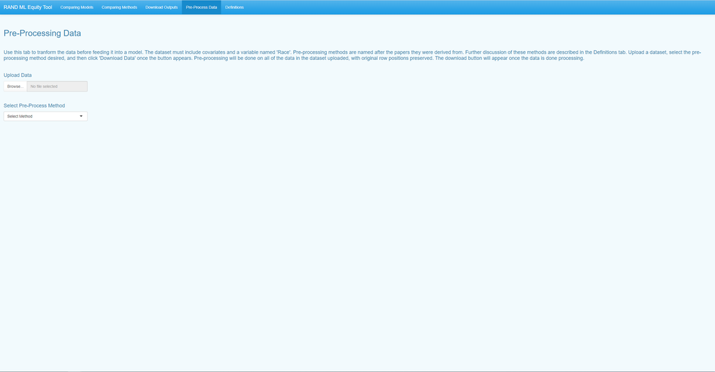

Figure 5: Generate Pre-Processed Data Tab

## 2.4 Download Outputs

The ‘Download Outputs’ tab allows you to download the data and/or plots produced by the three analytic tabs described in this section (i.e., the `Comparing Models`, `Comparing Post-Processing Methods`, and `Generate Pre-Processed Data` tabs). The output available for download on this tab depends on the inputs selected from each of the other tabs. After output has been generated by one of the analytic tabs, download buttons will appear in the `Download Outputs` tab in addition to a summary of the methods/metrics that have been selected. Data produced by each analytic tab will be output as a .xlsx file in the `Download Outputs` tab. Each sheet in the excel file will contain data for each model or method applied, with the last tab providing threshold information for each model or method selected. All plots produced by a single analytic tab will be output into one .png file.

The last tab provides definitions and citations for all of the terms mentioned in the first four tabs. There is also brief discussion of implementation of the methods.

## 2.6 Usage Notes

The tool can be run remotely on RAND’s RShiny server: https://rand.shinyapps.io/rand-ml-equity-tool/. Alternatively, the tool’s source code can be downloaded and run locally in. Using the local version may be preferable, for instance, a particular dataset cannot be uploaded onto the RShiny server due to privacy considerations. When using the tool locally, it will be neccessary to install the following packages and their dependencies: **shiny**, **shinyWidgets**, **grid**, **gridExtra**, **openxlsx**, **dplyr**, and **ggplot2**. General instructions for running RShiny apps can be found here: https://shiny.rstudio.com/articles/running.html.

# 3 Examples

In this section, we provide three examples illustrating the use of the tool. The first example shows how one can use the tool to compare alternative model fits from an equity perspective. The second example demonstrates how to take an existing dataset, apply a pre-processing algorithm to it, and then visualize differences in performance over the unaltered data. The final example demonstrates the post-processing methods.

In each of the examples below, we will use the simulated dataset `data.csv`, which is available in the tutorial folder.

```r
library(readr)
data = read_csv(file = "data.csv")
```

This dataset consists of the following variables

1. $G$: A binary indicator of a protected characteristic (e.g., race/ethnicity).
2. $Y$: The true binary outcome of interest.
3. $X$ and $L$: Covariates used to predict $Y$.

## 3.1 Comparing Models Example

In the first example, we will compare the equity characteristics of two alternative methods for predicting an outcome $Y$. The first method uses just $X$ to predict $Y$, while the second method uses $X$ and $L$ to predict $Y$. This type of setting may be useful when there is a concern that adding an additional covariate into a prediction model may have negative equity concerns. $X$ may be deemed a legitimate predictor of $Y$, while $L$ is a variable that is contested.

In the code below, we fit two logistic regression models that we use to predict $Y$. The predicted probability is used to derive binary predictions of the outcome by assigning individuals with predicted probabilities greater than 0.5 to the outcome 1 and individuals with predicted probabilities less than 0.5 to the outcome 0. Note that we can use any alternative classification algorithm within the `Comparing Models` tab.

```r
# Predictions from model 1
Prob1 = predict(glm(Y ~ X,  data = data, family = "binomial"), type = "response")
data$Prob1 = Prob1
data = mutate(data, Yhat1 = ifelse(Prob1 <= 0.5, 0, 1))

# Predictions from model 2
Prob2 = predict(glm(Y ~ X + L,  data = data, family = "binomial"), type = "response")
data$Prob2 = Prob2
data = mutate(data, Yhat2 = ifelse(Prob2 <= 0.5, 0, 1))
```

Next, we will write our files in the format expected by the tool. For the `Comparing Models` tab, the tool requires an input dataset containing the following three variables: 1. The protected characteristic `G` 2. The true outcome `Y` 3. The predicted outcome `Yhat` Other variables may be included, but are unnecessary and will be ignored by computations in this tab. In other tabs, the probabilities of classification ‘Prob’ will also be used. We include these in our output below to facilitate later examples.

```r
data1 = dplyr::select(data, Prob1, Yhat1, Y, G)
names(data1) = c("Prob", "Yhat", "Y", "G")
write_csv(data1, file = "sim_data1.csv")

data2 = dplyr::select(data, Prob2, Yhat2, Y, G)
names(data2) = c("Prob", "Yhat", "Y", "G")
write_csv(data2, file = "sim_data2.csv")
```

Once we have written these files, we can now use the `Compare Models` page to compare the equity characteristics of these models. A screen similar to Figure 6 should appear to compare the different methods. The scroll down menus allow the user to choose a metric to compare methods both in the whole population (using the **Overall Performance Metrics** menu) and across levels of the protected characteristic $G$ (using the **Subgroup Performance Metrics** menu). In Figure 6, we show the accuracy results for both the whole population and stratified by $G$. We notice the second method produces higher overall accuracy. Examining the performance at each level of the protected class $G$, we notice that not only does the second method produce higher accuracy overall, but that discrepancies in performance are smaller across $G$ as well.

[figure not shown]

Figure 6: Comparing Two Different Models

## 3.2 Post Processing Example

Several post-processing methods can be performed on the outputs of any single model by using the `Comparing Methods` tab of the RAND Equity Tool. However, this tab requires a variable called `Prob` in addition to the three variables required by the `Comparing Models` tab. The variable `Prob` is the predicted probability that the binary outcome $Y$ equals 1 for each individual.

As an example of the `Comparing Methods` tab, we upload `sim_data2.csv`. Note that it may take a couple minutes for the plots to generate as the tool processes all of the methods beforehand. Once the plots have appeared onto the screen, we select all of the Post-Processing Methods available, producing Figure 7. The Subgroup Performance Metrics menu allows the user to select an equity metric to compare post-processing methods on. First, we select Statistical Parity under the Subgroup Performance Metrics option. We leave the Overall Performance Metrics as Overall Accuracy. Unsurprisingly, we notice the Statistical Parity post-processing method produces the most equitable outcomes in terms of postive labels for both races. We also notice that none of the post-processing methods affect accuracy too much, which could simplify our decision for determining which post-processing method to use.

[figure not shown]

[figure not shown]

Figure 8: Comparing False Negative Rate Among Post Processed Data

The produced plots can be downloaded from the `Download Outputs` tab. This time, we notice download buttons appearing under the section titled ‘Comparing Methods tab’. We also see the options we have selected from this tab. If we wish to download either of the plots or the data, we can click on the appropriate download button.

## 3.3 Pre-Processing Example

In this example, we apply a pre-processing method to remove the effects of `G` from a dataset in order to mitigate potential correlated effects it may have with other covariates.

[figure not shown]

Figure 9: Pre-Process Data File Upload

Now that we have obtained our pre-processed dataset, we will now re-fit our model usign the pre-processed data. Below, we fit a logistic regression analogous to Model 2 in the section above, but using the pre-processed data rather than the original data. Again, we save the resulting output.

```r
# TODO: when sending tutorial folder, only include data.csv for only data file
data_preprocess = read_csv(file = "johndrow_lum_preprocessed_data.csv", show_col_types = FALSE)

# Predictions from pre-processed data
rhat = predict(glm(Y ~ X + L,  data = data_preprocess, family = "binomial"), type = "response")
data_preprocess$rhat = rhat
data_preprocess = mutate(data_preprocess, Yhat = ifelse(rhat <= 0.5, 0, 1))

data_preprocess = dplyr::select(data_preprocess, rhat, Yhat, Y, G)
names(data_preprocess) = c("Prob", "Yhat", "Y", "G")
write_csv(data_preprocess, file = "model_output_predictions2_preprocessed.csv")
```

The plots produced can be downloaded from the `Download Outputs` tab. Under the section titled ‘Comparing Models’, there is a button to download the plots as well as the metrics we have selected from the `Comparing Models` tab, as in Figure 12. You can optionally name the plot file using the ‘Title of Saved Plots’ text box before downloading.

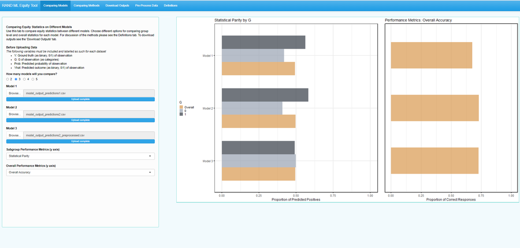

Figure 10: Comparing Preprocessed Data to Original for Statistical Parity

[figure not shown]

Figure 11: Comparing Preprocessed Data to Original for False Negative Rates

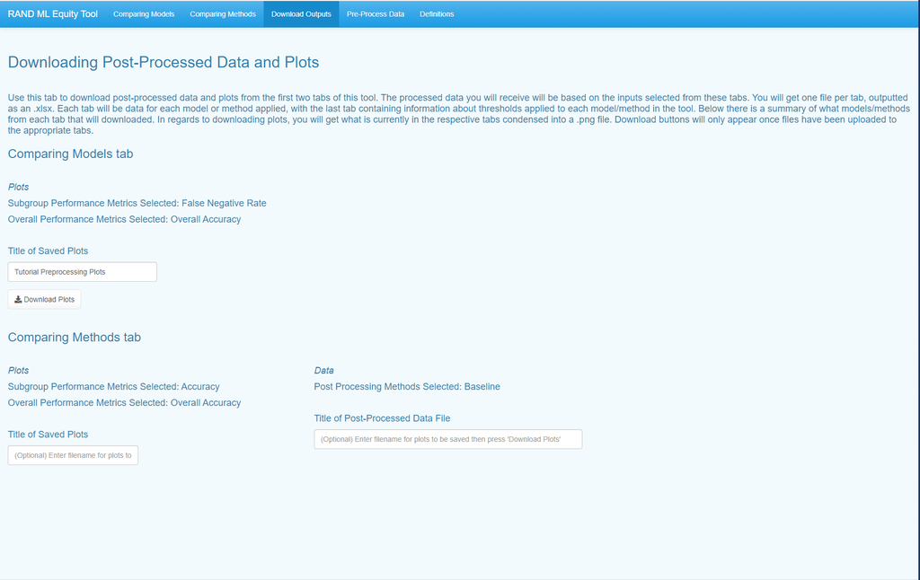

Figure 12: Downloading Output from ‘Comparing Models’ Tab